# fcbc_sr_v1

*Data compiled from source on 14 October 2021 (11:35).*

# Data prep

## R setup

Load packages and set options

```r
# load vector and raster packages
xfun::pkg_attach("ggplot2", "tidyr", "dplyr")

# options
options(tibble.width = 120, tibble.print_min = 15, pillar.min_title_chars = 15, dplyr.summarise.inform = FALSE)

# set working directory (for interactive console)
setwd("C:/DataProjects/fcbc")
```

## Import data

Get data from Google sheet

```r
# first get the column names
headers <- read.csv("https://docs.google.com/spreadsheets/d/e/2PACX-1vT_U2jN0hFq4aE6LP1e8Xn1_Oec6l_vngi18GR3ATR78HNR0jccePLg35IsX0Lp2eHrcCGm2zMHG0is/pub?gid=0&single=true&output=csv", header = FALSE, skip = 1, nrows = 1)

# then get the actual data and assign column names
data_csv <- read.csv("https://docs.google.com/spreadsheets/d/e/2PACX-1vT_U2jN0hFq4aE6LP1e8Xn1_Oec6l_vngi18GR3ATR78HNR0jccePLg35IsX0Lp2eHrcCGm2zMHG0is/pub?gid=0&single=true&output=csv", header = FALSE, skip = 3, col.names = headers)

# as tibble -- also useful for re-running code without https call
data <- as_tibble(data_csv)

# export for sharing
write.csv(data, "fcbc_sr_v1.csv")
```

## Add UNSD info

Adds fields on UN region, etc.

```r
# first need to separate out multiple countries
data <- data %>% separate_rows(location, sep = "(,\\s)")

# get unsd data
unsd <- read.csv("C:/DataProjects/fcbc/unsd_m49.csv")

# select data
unsd <- as_tibble(unsd) %>% select(Region.Code:Sub.region.Name, Country.or.Area, M49.Code, ISO.alpha3.Code, Developed...Developing.Countries)

# rename columns
unsd <- unsd %>% rename(country_name = Country.or.Area, region_code = Region.Code, region_name = Region.Name, subregion_code = Sub.region.Code, subregion_name = Sub.region.Name, country_m49 = M49.Code, country_iso3 = ISO.alpha3.Code, development_cat = Developed...Developing.Countries)

# join to data
data <- left_join(data, unsd, by = c("location" = "country_name"))
```

## Merge fisheries use types

Consolidate subsistence and commercial fisheries into single variable.

```r
data <- data %>% mutate(use_fisheries = case_when(
  use_subsistence_fisheries == TRUE | use_commercial_fisheries == TRUE ~ TRUE,
  TRUE ~ FALSE
))

data <- data %>% select(-use_subsistence_fisheries, -use_commercial_fisheries)
```

## Restructure data

Move from ‘wide’ to ‘long’ table, consolidating columns which represent multiple values for a single record.

```r
# inspect data and check variable types -- looks okay except for characters which should be factors
str(data)

# replace blanks with NA
data[data == ""] <- NA

# pivot longer for FWE type
data <- pivot_longer(data, starts_with("fwe_") & !ends_with("fwe_other"), names_to = "fwe_type", names_prefix = "(fwe_)", values_to = "fwe_log")
# pivot longer for FW use type
data <- pivot_longer(data, starts_with("use_") & !ends_with("use_other"), names_to = "use_type", names_prefix = "(use_)", values_to = "use_log")

# pivot longer for project action type
data <- pivot_longer(data, starts_with("act_") & !ends_with("act_other"), names_to = "action_type", names_prefix = "(act_)", values_to = "action_log")

# pivot longer for environmental outcome type
data <- pivot_longer(data, starts_with("eout_") & !starts_with("eout_other"), names_to = "enviroOutcome_type", names_prefix = "(eout_)", values_to = "enviroOutcome_effect")

# pivot longer for HWB outcome type
data <- pivot_longer(data, starts_with("hout_") & !starts_with("hout_other"), names_to = "hwbOutcome_type", names_prefix = "(hout_)", values_to = "hwbOutcome_effect")

# reorder columns
data <- data %>% relocate(id:location, fwe_type, fwe_log, fwe_other, use_type, use_log, use_other, action_type, action_log, act_other, enviroOutcome_type:hwbOutcome_effect)

# rename columns with non-verbose names
data <- data %>% rename(enviroOutcome_other = eout_other, enviroOutcome_other_effect = eout_other_effect, hwbOutcome_other = hout_other, hwbOutcome_other_effect = hout_other_effect, action_other = act_other)

# inspect revised data
str(data)
```

## Recategorize FWEs

Regroup FWE categories by merging similar groups:

- Combine ‘seasonal lakes’ and ‘seasonal floodplain/marshes’
- Combine ‘groundwater’ and ‘springs’
- Combine ‘canals, ditches and drains’ and ‘other artificial’

```r
data <- data %>% mutate(fwe_type2 = case_when(
  fwe_type %in% c("lakes_seasonal", "marshes_seasonal") ~ "lakes_marshes_seasonal",
  fwe_type %in% c("groundwater", "springs") ~ "groundwater_springs",
  fwe_type %in% c("canal", "other_artificial") ~ "other_artificial",
  fwe_type %in% c("marshes_permanent", "other_wetlands") ~ "marshes_permanent",
  TRUE ~ fwe_type
))
```

# Results

## Coding status

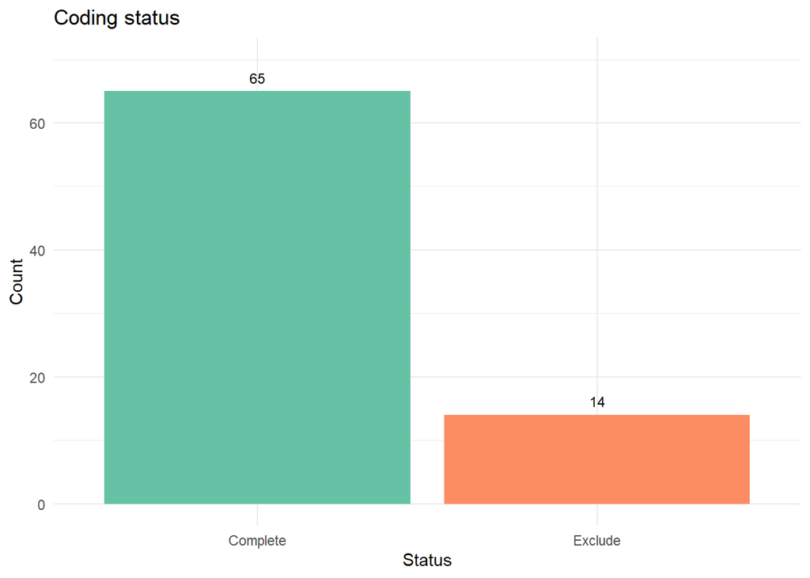

```r
plot <- data %>% select(id, status) %>% distinct()
colors <- scale_fill_brewer(palette = "Set2")
theme <- theme_minimal()
labels <- labs(title = "Coding status", fill = "Status", x = "Status", y = "Count")

ggplot(plot, aes(x = status)) + geom_bar(aes(fill = status), show.legend = FALSE) + geom_text(stat = "count", size = 3, aes(label = ..count..), vjust = -0.75) + ylim(c(0, 70)) + colors + theme + labels
```

## Study attributes

*Only papers marked “Complete” are included in the displayed results.*

```r
fdata <- data %>% filter(status == "Complete")
```

### Publication date

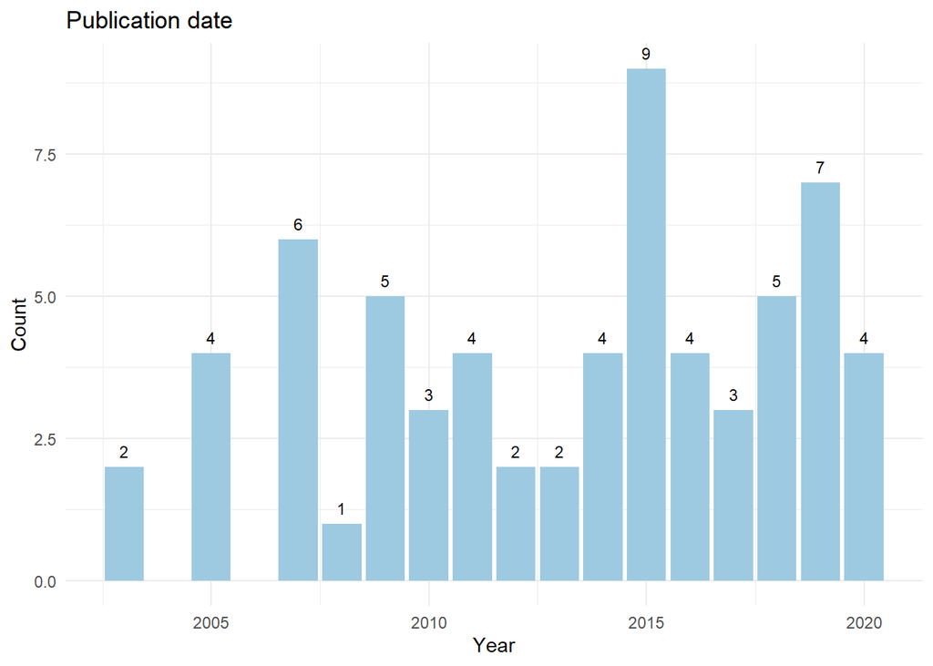

```r
plot <- fdata %>% select(id, pub_date) %>% distinct()
theme <- theme_minimal()
color <- "#9ECAE1"
labels <- labs(title = "Publication date", x = "Year", y = "Count")

ggplot(plot, aes(x = pub_date)) + geom_bar(fill = color, show.legend = FALSE) + geom_text(stat = "count", size = 3, aes(label = ..count..), vjust = -0.75)  + theme + labels
```

### Study design (primary)

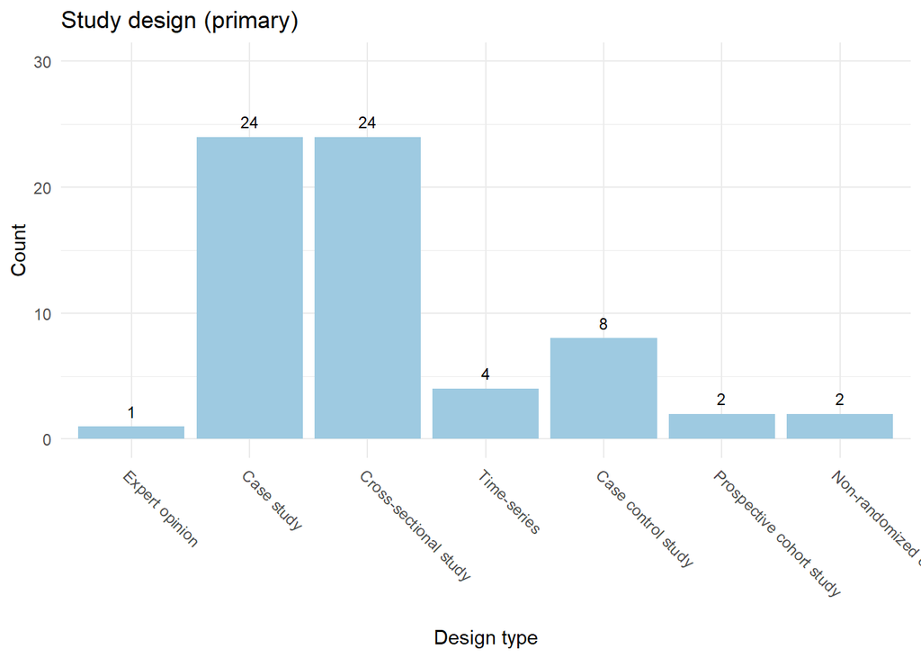

```r
plot <- fdata %>% select(id, study_design1) %>% distinct()
plot <- plot %>% mutate(study_design1 = factor(study_design1, levels = c("Expert opinion", "Case study", "Cross-sectional study", "Time-series", "Case control study", "Prospective cohort study", "Non-randomized control study")))
theme <- theme_minimal()
color <- "#9ECAE1"
labels <- labs(title = "Study design (primary)", x = "Design type", y = "Count")

ggplot(plot, aes(x = study_design1)) + geom_bar(fill = color, show.legend = FALSE) + geom_text(stat = "count", size = 3, aes(label = ..count..), vjust = -0.75)  + theme + labels + theme(axis.text.x = element_text(angle = -45, hjust = 0)) + ylim(c(0, 30))
```

### Study design (primary & secondary)

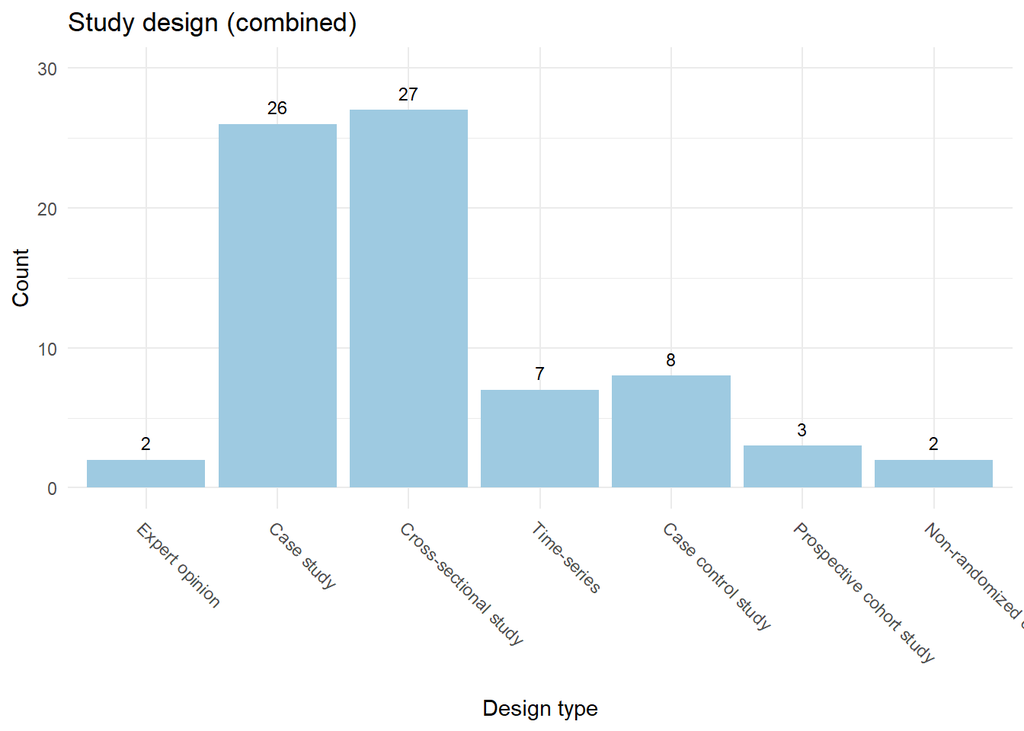

```r
plot <- fdata %>% select(id, study_design1, study_design2) %>% distinct()
plot <- pivot_longer(plot, starts_with("study_design"), names_to = "study_design_field", values_to = "study_design", values_drop_na = TRUE)
plot <- plot %>% mutate(study_design = factor(study_design, levels = c("Expert opinion", "Case study", "Cross-sectional study", "Time-series", "Case control study", "Prospective cohort study", "Non-randomized control study")))
theme <- theme_minimal()
color <- "#9ECAE1"
labels <- labs(title = "Study design (combined)", x = "Design type", y = "Count")

ggplot(plot, aes(x = study_design)) + geom_bar(fill = color, show.legend = FALSE) + geom_text(stat = "count", size = 3, aes(label = ..count..), vjust = -0.75)  + theme + labels + theme(axis.text.x = element_text(angle = -45, hjust = 0)) + ylim(c(0, 30))
```

### Equity subgroup analyses

```r
fdata %>% select(id, study_subgroup) %>% distinct() %>% filter(!is.na(study_subgroup)) %>% group_by(study_subgroup) %>% tally() %>% knitr::kable("simple")
```

| study_subgroup | n |
| --- | --- |
| Canal location (head/middle/tail) | 1 |
| Canal location (head/tail) | 1 |
| Caste system | 1 |
| considered youth and women when interviewing and information collection | 1 |
| Elite status | 1 |
| Farm size, farm type, number of income sources, canal location (head/tail) | 1 |
| farmers with different levels of access to the resource | 1 |
| Fishers | 1 |
| gender | 5 |
| Gender | 1 |
| gender (women), caste | 1 |
| Gender, age, education | 1 |
| gender, ethnic divisions, geographic expanse | 1 |
| high income vs. low income farmers | 1 |
| Livelihood type, land ownership status | 1 |
| poor floodplain users, women | 1 |
| poor, youth, and female-headed farmers participating in the scheme; positive outcome for all three groups | 1 |
| position along canals (head, middle, tail) | 1 |
| social categories - caste and tribe; farm sizes (marginal and small scale farmers) | 1 |
| water delivery/distribution between users (location along canals) | 1 |
| Women | 3 |
| WUAs | 1 |

## Study location

*Only papers marked “Complete” are included in the displayed results.*

### UN region

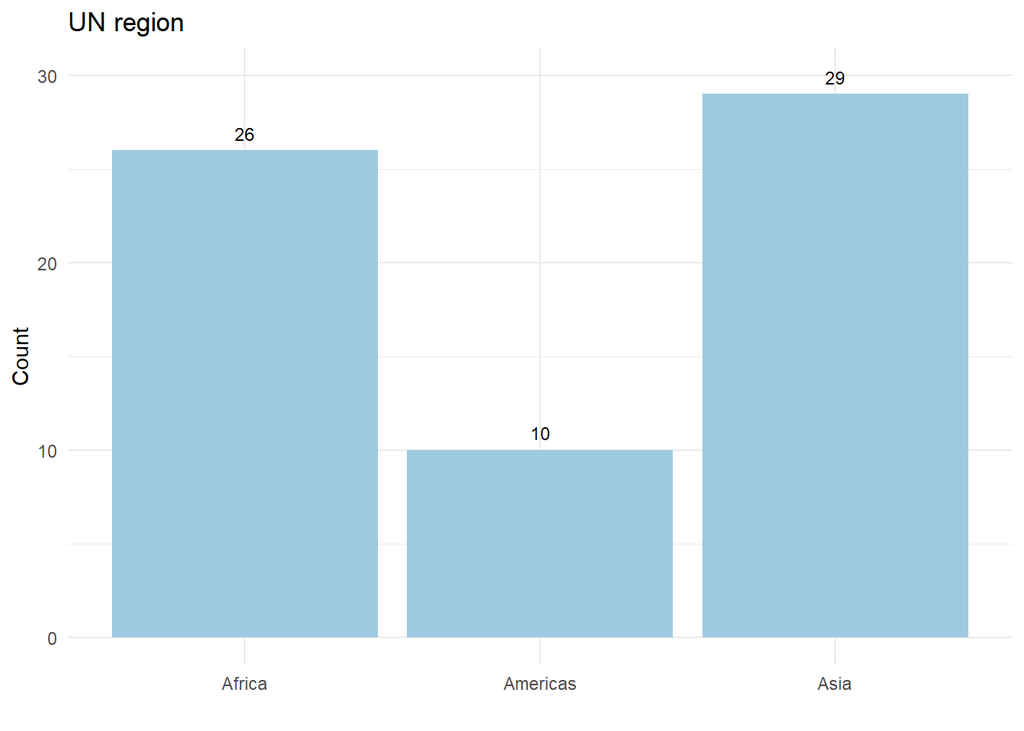

```r
plot <- fdata %>% select(id, region_name) %>% distinct()
color <- "#9ECAE1"
theme <- theme_minimal()
labels <- labs(title = "UN region", x = "", y = "Count")

ggplot(plot, aes(x = region_name)) + geom_bar(fill = color, show.legend = FALSE) + geom_text(stat = "count", size = 3, aes(label = ..count..), vjust = -0.75) + ylim(c(0, 30)) + theme + labels
```

### UN subregion

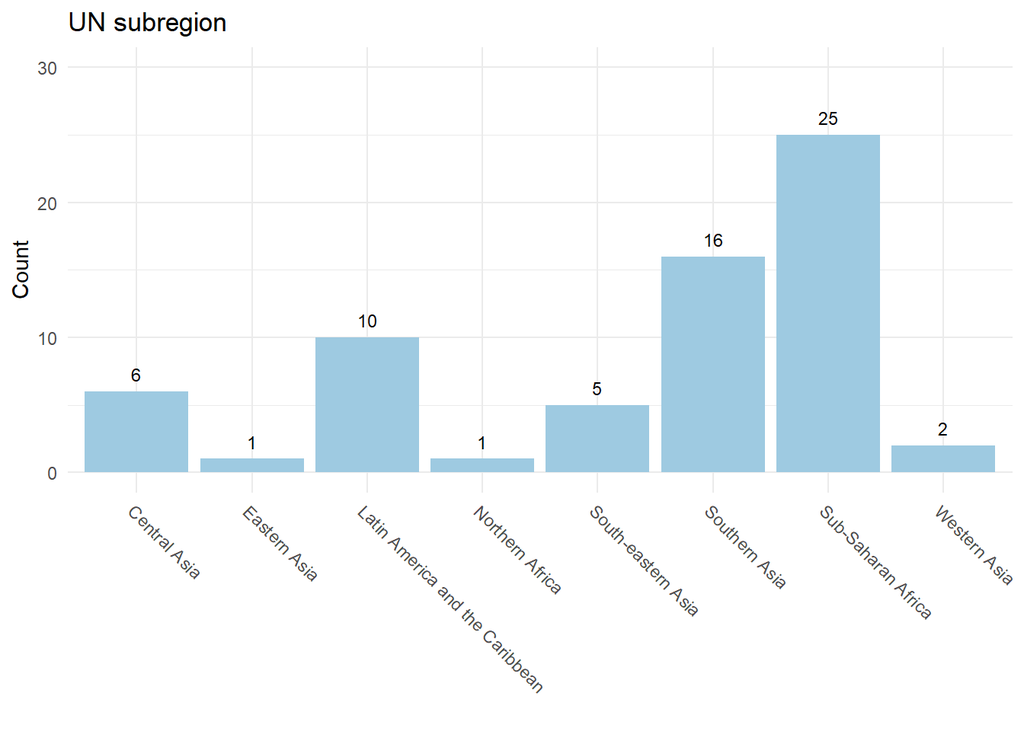

```r
plot <- fdata %>% select(id, subregion_name) %>% distinct()
color <- "#9ECAE1"
theme <- theme_minimal()
labels <- labs(title = "UN subregion", x = "", y = "Count")

ggplot(plot, aes(x = subregion_name)) + geom_bar(fill = color, show.legend = FALSE) + geom_text(stat = "count", size = 3, aes(label = ..count..), vjust = -0.75) + ylim(c(0, 30)) + theme + labels + theme(axis.text.x = element_text(angle = -45, hjust = 0))
```

### Country (map)

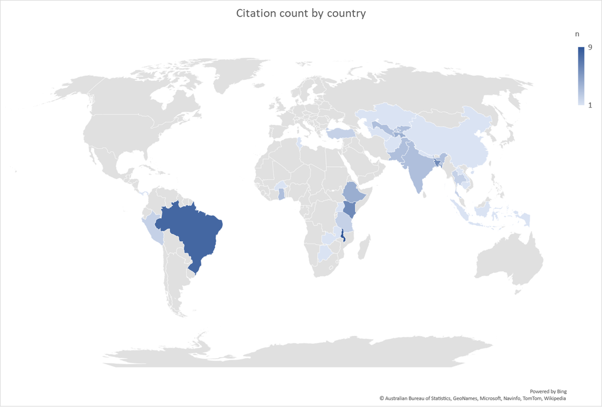

### Country (table)

```r
fdata %>% select(id, location) %>% distinct() %>% group_by(location) %>% tally() %>% arrange(-n) %>% knitr::kable("simple")
```

| location | n |
| --- | --- |
| Malawi | 9 |
| Brazil | 8 |
| Bangladesh | 7 |
| Kenya | 6 |
| Ethiopia | 4 |
| Tajikistan | 4 |
| Ghana | 3 |
| India | 3 |
| Kyrgyzstan | 3 |
| Pakistan | 3 |
| Uzbekistan | 3 |
| Nepal | 2 |
| Peru | 2 |
| Thailand | 2 |
| Turkey | 2 |
| United Republic of Tanzania | 2 |
| Afghanistan | 1 |
| Botswana | 1 |
| Burkina Faso | 1 |
| Cambodia | 1 |
| China | 1 |
| Indonesia | 1 |
| Kazakhstan | 1 |
| Lao People’s Democratic Republic | 1 |
| Tunisia | 1 |
| Turkmenistan | 1 |
| Uganda | 1 |
| Zambia | 1 |

## Project attributes

*Only papers marked “Complete” are included in the displayed results.*

### Freshwater ecosystem (FWE) types

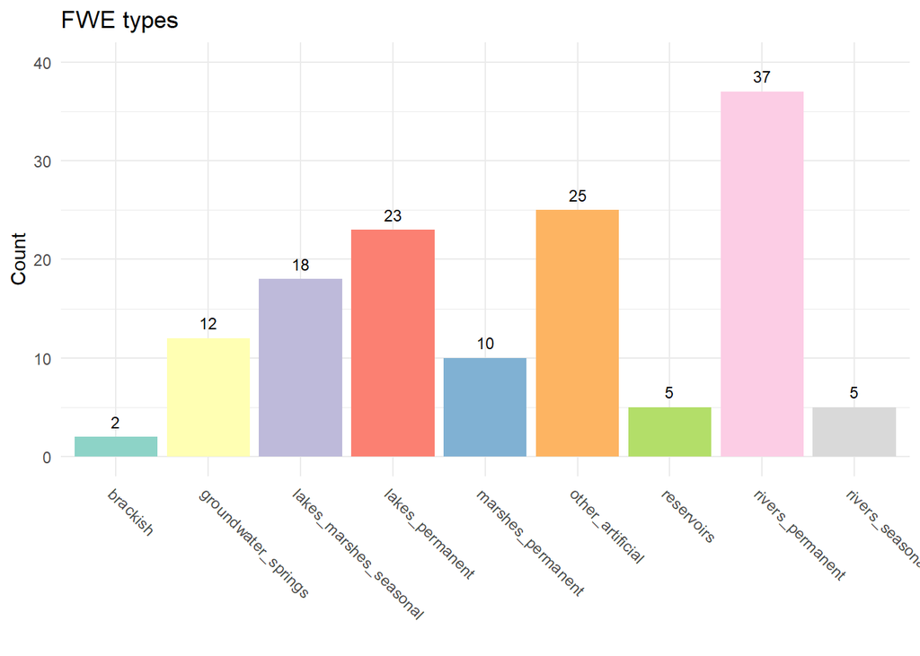

```r
plot <- fdata %>% select(id, fwe_type2, fwe_log) %>% filter(fwe_log == TRUE) %>% distinct()
colors <- scale_fill_brewer(palette = "Set3")
theme <- theme_minimal()
labels <- labs(title = "FWE types", x = "", y = "Count")

ggplot(plot, aes(x = fwe_type2)) + geom_bar(aes(fill = fwe_type2), show.legend = FALSE) + geom_text(stat = "count", size = 3, aes(label = ..count..), vjust = -0.75) + ylim(c(0, 40)) + theme + labels + colors + theme(axis.text.x = element_text(angle = -45, hjust = 0))
```

Other FWE types:

```r
fdata %>% select(id, fwe_other) %>% filter(!is.na(fwe_other)) %>% distinct() %>% group_by(fwe_other) %>% tally() %>% knitr::kable("simple")
```

| fwe_other | n |
| --- | --- |
| actual source of irrigation water not specifically mentioned but probably varies across study group | 1 |
| Brackish lagoon | 1 |
| brackish tidal swamps | 1 |
| irrigation | 2 |
| Irrigation | 1 |
| permanent floodplain area (different from lakes?) | 1 |
| Permanent floodplain lakes | 1 |
| permanent floodplain lakes/marshes (do we consider it different from permanent lakes?) | 1 |
| Rice fields, irrigation ponds | 1 |
| small reservoirs and irrigation | 1 |
| Water source only noted for a subset of projects so FWE is incomplete | 1 |

### Community freshwater use types

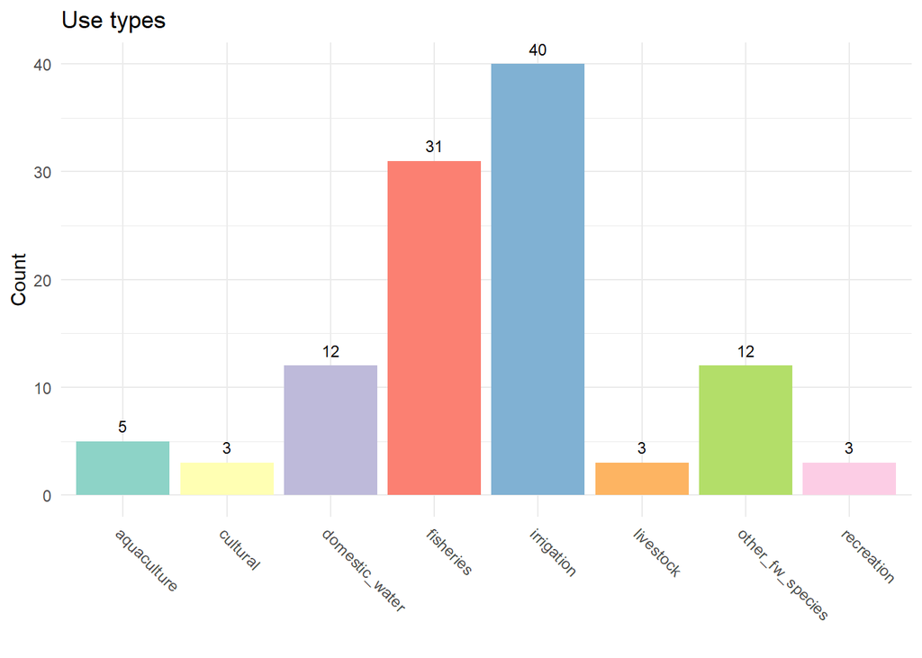

```r
plot <- fdata %>% select(id, use_type, use_log) %>% filter(use_log == TRUE) %>% distinct()
colors <- scale_fill_brewer(palette = "Set3")
theme <- theme_minimal()
labels <- labs(title = "Use types", x = "", y = "Count")

ggplot(plot, aes(x = use_type)) + geom_bar(aes(fill = use_type), show.legend = FALSE) + geom_text(stat = "count", size = 3, aes(label = ..count..), vjust = -0.75) + ylim(c(0, 40)) + theme + labels + colors + theme(axis.text.x = element_text(angle = -45, hjust = 0))
```

Other community FW use types:

```r
fdata %>% select(id, use_other) %>% filter(!is.na(use_other)) %>% distinct() %>% group_by(use_other) %>% tally() %>% knitr::kable("simple")
```

| use_other | n |
| --- | --- |
| Fish waste as fertilizer | 1 |
| Grazing; converting wetland/dambos to ag fields | 1 |
| horticulture | 1 |
| livestock | 1 |
| Livestock rearing | 1 |
| transportation/navigation | 1 |

### Project action types

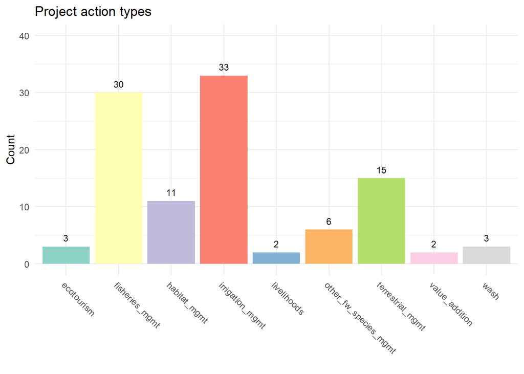

```r
plot <- fdata %>% select(id, action_type, action_log) %>% filter(action_log == TRUE) %>% distinct()
colors <- scale_fill_brewer(palette = "Set3")
theme <- theme_minimal()
labels <- labs(title = "Project action types", x = "", y = "Count")

ggplot(plot, aes(x = action_type)) + geom_bar(aes(fill = action_type), show.legend = FALSE) + geom_text(stat = "count", size = 3, aes(label = ..count..), vjust = -0.75) + ylim(c(0, 40)) + theme + labels + colors + theme(axis.text.x = element_text(angle = -45, hjust = 0))
```

Other project action types:

```r
fdata %>% select(id, action_other) %>% filter(!is.na(action_other)) %>% distinct() %>% group_by(action_other) %>% tally() %>% knitr::kable("simple")
```

| action_other | n |
| --- | --- |
| Alternative livelihoods | 1 |
| Alternative livelihoods, learning centers | 1 |
| Aquaculture | 1 |
| Awareness raising, income diversification, capacity building | 1 |
| credit, clarification of rights | 1 |
| Dam construction for livestock and domestic water use | 1 |
| Monitoring | 1 |
| Some provided credit, clarification of fishing rights | 1 |

## Environmental outcomes

*Only papers marked “Complete” are included in the displayed results.*

### Type

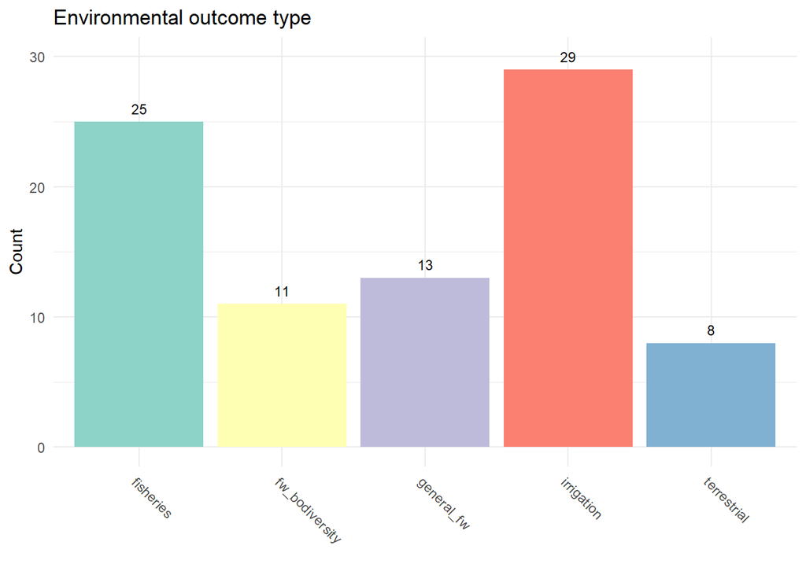

```r
plot <- fdata %>% select(id, enviroOutcome_type, enviroOutcome_effect) %>% filter(!is.na(enviroOutcome_effect)) %>% distinct()
colors <- scale_fill_brewer(palette = "Set3")
theme <- theme_minimal()
labels <- labs(title = "Environmental outcome type", x = "", y = "Count")

ggplot(plot, aes(x = enviroOutcome_type)) + geom_bar(aes(fill = enviroOutcome_type), show.legend = FALSE) + geom_text(stat = "count", size = 3, aes(label = ..count..), vjust = -0.75) + ylim(c(0, 30)) + theme + labels + colors + theme(axis.text.x = element_text(angle = -45, hjust = 0))
```

Other outcome types:

```r
fdata %>% select(id, enviroOutcome_other) %>% distinct() %>%  group_by(enviroOutcome_other) %>% tally() %>% knitr::kable("simple")
```

| enviroOutcome_other | n |
| --- | --- |
| NA | 65 |

### Effect

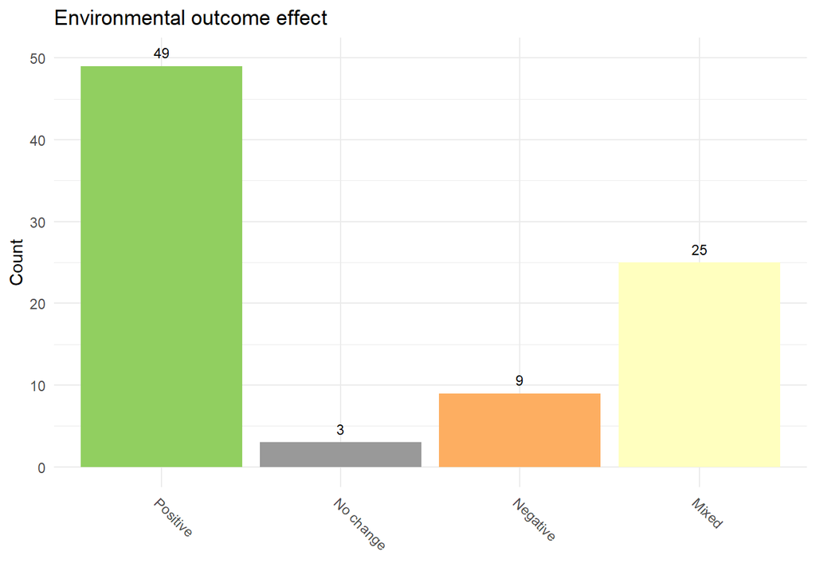

```r
plot <- fdata %>% select(id, enviroOutcome_type, enviroOutcome_effect) %>% filter(!is.na(enviroOutcome_effect)) %>% distinct()
plot <- plot %>% mutate(enviroOutcome_effect = factor(enviroOutcome_effect, levels = c("Positive", "No change", "Negative",  "Mixed"), ordered = TRUE))
colors <- c("#91cf60", "#999999", "#fdae61", "#ffffbf")
theme <- theme_minimal()
labels <- labs(title = "Environmental outcome effect", x = "", y = "Count")

ggplot(plot, aes(x = enviroOutcome_effect)) + geom_bar(aes(fill = enviroOutcome_effect), show.legend = FALSE) + geom_text(stat = "count", size = 3, aes(label = ..count..), vjust = -0.75) + ylim(c(0, 50)) + theme + labels + theme(axis.text.x = element_text(angle = -45, hjust = 0)) + scale_fill_manual(values = colors)
```

### Effect by type

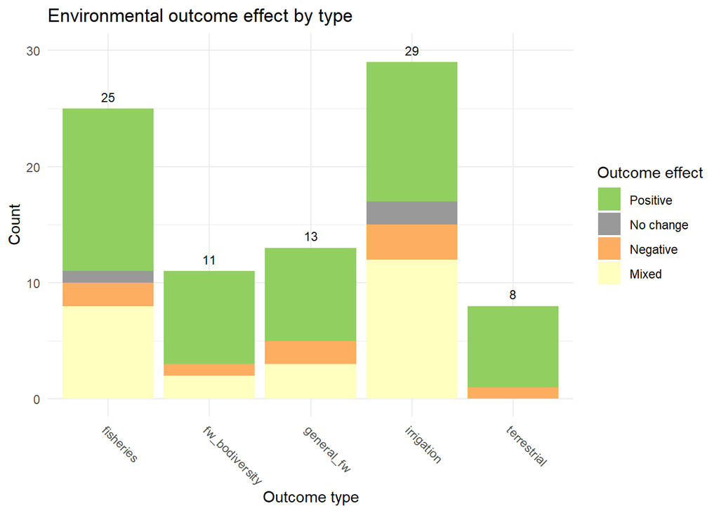

```r
plot <- fdata %>% select(id, enviroOutcome_type, enviroOutcome_effect) %>% filter(!is.na(enviroOutcome_effect)) %>% distinct()
plot <- plot %>% mutate(enviroOutcome_effect = factor(enviroOutcome_effect, levels = c("Positive", "No change", "Negative",  "Mixed"), ordered = TRUE))
colors <- c("#91cf60", "#999999", "#fdae61", "#ffffbf")
theme <- theme_minimal()
labels <- labs(title = "Environmental outcome effect by type", x = "Outcome type", y = "Count", fill = "Outcome effect")

ggplot(plot, aes(x = enviroOutcome_type)) + geom_bar(aes(fill = enviroOutcome_effect)) + geom_text(stat = "count", size = 3, aes(label = ..count..), vjust = -0.75) + ylim(c(0, 30)) + theme + labels + theme(axis.text.x = element_text(angle = -45, hjust = 0)) + scale_fill_manual(values = colors)
```

### Effect by type (%)

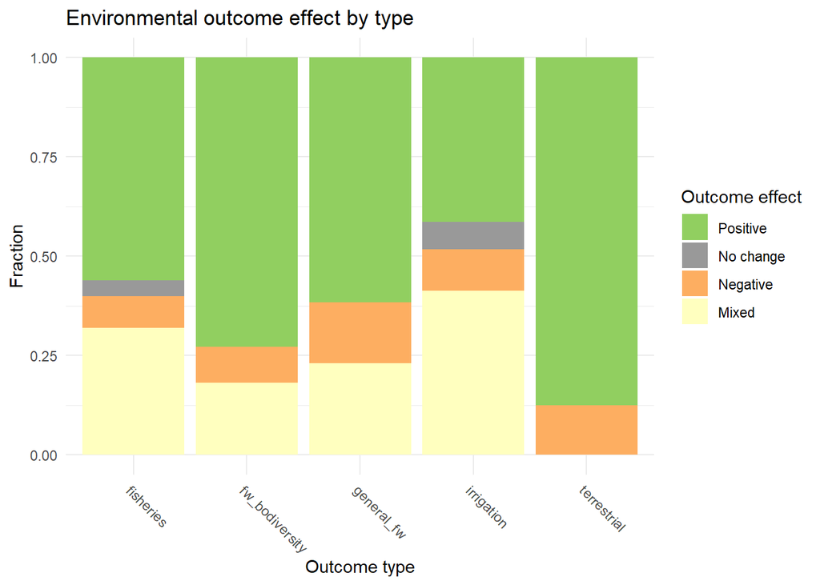

```r
plot <- fdata %>% select(id, enviroOutcome_type, enviroOutcome_effect) %>% filter(!is.na(enviroOutcome_effect)) %>% distinct()
plot <- plot %>% mutate(enviroOutcome_effect = factor(enviroOutcome_effect, levels = c("Positive", "No change", "Negative",  "Mixed"), ordered = TRUE))
colors <- c("#91cf60", "#999999", "#fdae61", "#ffffbf")
theme <- theme_minimal()
labels <- labs(title = "Environmental outcome effect by type", x = "Outcome type", y = "Fraction", fill = "Outcome effect")

ggplot(plot, aes(x = enviroOutcome_type, fill = enviroOutcome_effect)) + geom_bar(position = "fill") + theme + labels + theme(axis.text.x = element_text(angle = -45, hjust = 0)) + scale_fill_manual(values = colors)
```

### Type by effect

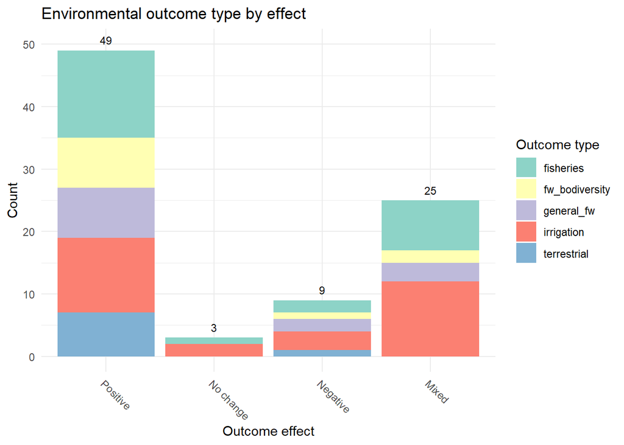

```r
plot <- fdata %>% select(id, enviroOutcome_type, enviroOutcome_effect) %>% filter(!is.na(enviroOutcome_effect)) %>% distinct()
plot <- plot %>% mutate(enviroOutcome_effect = factor(enviroOutcome_effect, levels = c("Positive", "No change", "Negative",  "Mixed"), ordered = TRUE))
colors <- scale_fill_brewer(palette = "Set3")
theme <- theme_minimal()
labels <- labs(title = "Environmental outcome type by effect", x = "Outcome effect", y = "Count", fill = "Outcome type")

ggplot(plot, aes(x = enviroOutcome_effect)) + geom_bar(aes(fill = enviroOutcome_type)) + geom_text(stat = "count", size = 3, aes(label = ..count..), vjust = -0.75) + ylim(c(0, 50)) + theme + labels + theme(axis.text.x = element_text(angle = -45, hjust = 0)) + colors
```

## Human well-being outcomes

*Only papers marked “Complete” are included in the displayed results.*

### Type

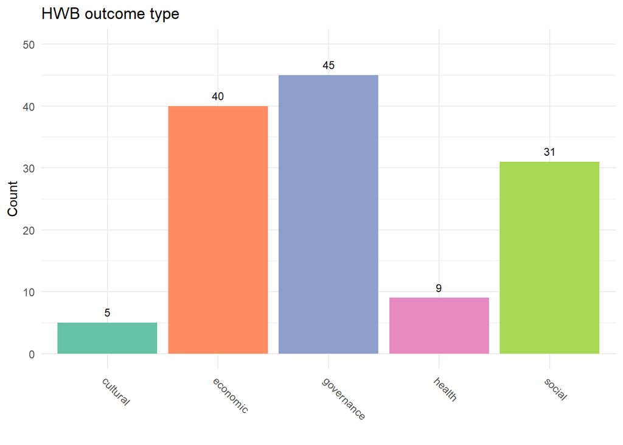

```r
plot <- fdata %>% select(id, hwbOutcome_type, hwbOutcome_effect) %>% filter(!is.na(hwbOutcome_effect)) %>% distinct()
colors <- scale_fill_brewer(palette = "Set2")
theme <- theme_minimal()
labels <- labs(title = "HWB outcome type", x = "", y = "Count")

ggplot(plot, aes(x = hwbOutcome_type)) + geom_bar(aes(fill = hwbOutcome_type), show.legend = FALSE) + geom_text(stat = "count", size = 3, aes(label = ..count..), vjust = -0.75) + ylim(c(0, 50)) + theme + labels + colors + theme(axis.text.x = element_text(angle = -45, hjust = 0))
```

Other outcome types:

```r
fdata %>% select(id, hwbOutcome_other) %>% distinct() %>%  group_by(hwbOutcome_other) %>% tally() %>% knitr::kable("simple")
```

| hwbOutcome_other | n |
| --- | --- |
| NA | 65 |

### Effect

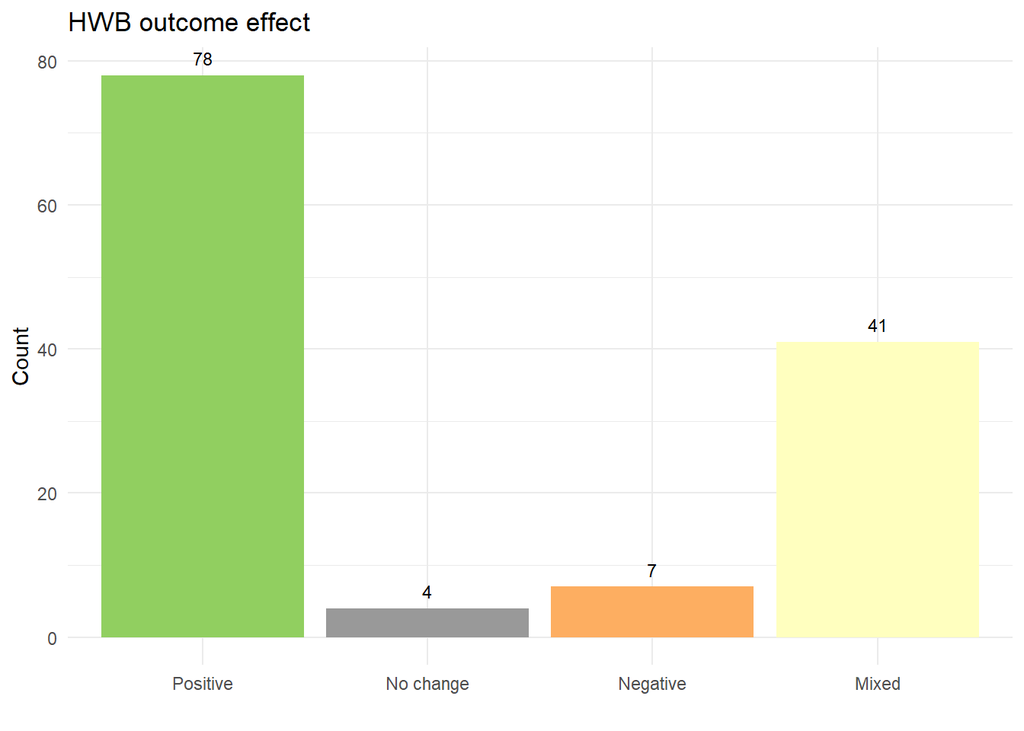

```r
plot <- fdata %>% select(id, hwbOutcome_type, hwbOutcome_effect) %>% filter(!is.na(hwbOutcome_effect)) %>% distinct()
plot <- plot %>% mutate(hwbOutcome_effect = factor(hwbOutcome_effect, levels = c("Positive", "No change", "Negative",  "Mixed"), ordered = TRUE))
colors <- c("#91cf60", "#999999", "#fdae61", "#ffffbf")
theme <- theme_minimal()
labels <- labs(title = "HWB outcome effect", x = "", y = "Count")

ggplot(plot, aes(x = hwbOutcome_effect)) + geom_bar(aes(fill = hwbOutcome_effect), show.legend = FALSE) + geom_text(stat = "count", size = 3, aes(label = ..count..), vjust = -0.75) + theme + labels + scale_fill_manual(values = colors)
```

### Effect by type

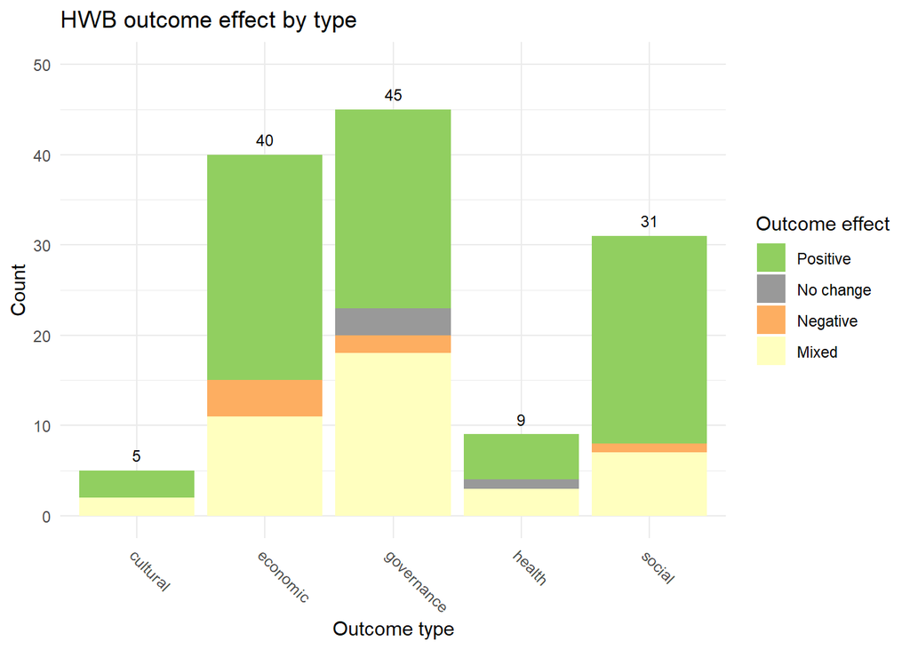

```r
plot <- fdata %>% select(id, hwbOutcome_type, hwbOutcome_effect) %>% filter(!is.na(hwbOutcome_effect)) %>% distinct()
plot <- plot %>% mutate(hwbOutcome_effect = factor(hwbOutcome_effect, levels = c("Positive", "No change", "Negative",  "Mixed"), ordered = TRUE))
colors <- c("#91cf60", "#999999", "#fdae61", "#ffffbf")
theme <- theme_minimal()
labels <- labs(title = "HWB outcome effect by type", x = "Outcome type", y = "Count", fill = "Outcome effect")

ggplot(plot, aes(x = hwbOutcome_type)) + geom_bar(aes(fill = hwbOutcome_effect)) + geom_text(stat = "count", size = 3, aes(label = ..count..), vjust = -0.75) + ylim(c(0, 50)) + theme + labels + theme(axis.text.x = element_text(angle = -45, hjust = 0)) + scale_fill_manual(values = colors)
```

### Effect by type (%)

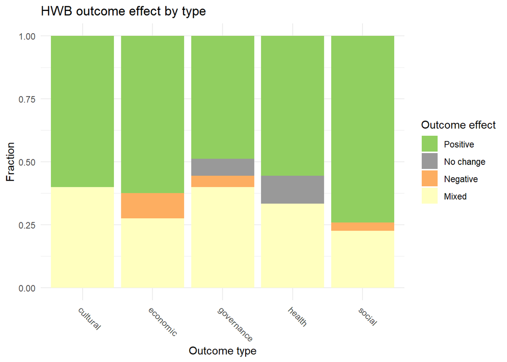

```r
plot <- fdata %>% select(id, hwbOutcome_type, hwbOutcome_effect) %>% filter(!is.na(hwbOutcome_effect)) %>% distinct()
plot <- plot %>% mutate(hwbOutcome_effect = factor(hwbOutcome_effect, levels = c("Positive", "No change", "Negative",  "Mixed"), ordered = TRUE))
colors <- c("#91cf60", "#999999", "#fdae61", "#ffffbf")
theme <- theme_minimal()
labels <- labs(title = "HWB outcome effect by type", x = "Outcome type", y = "Fraction", fill = "Outcome effect")

ggplot(plot, aes(x = hwbOutcome_type, fill = hwbOutcome_effect)) + geom_bar(position = "fill") + theme + labels + theme(axis.text.x = element_text(angle = -45, hjust = 0)) + scale_fill_manual(values = colors)
```

### Type by effect

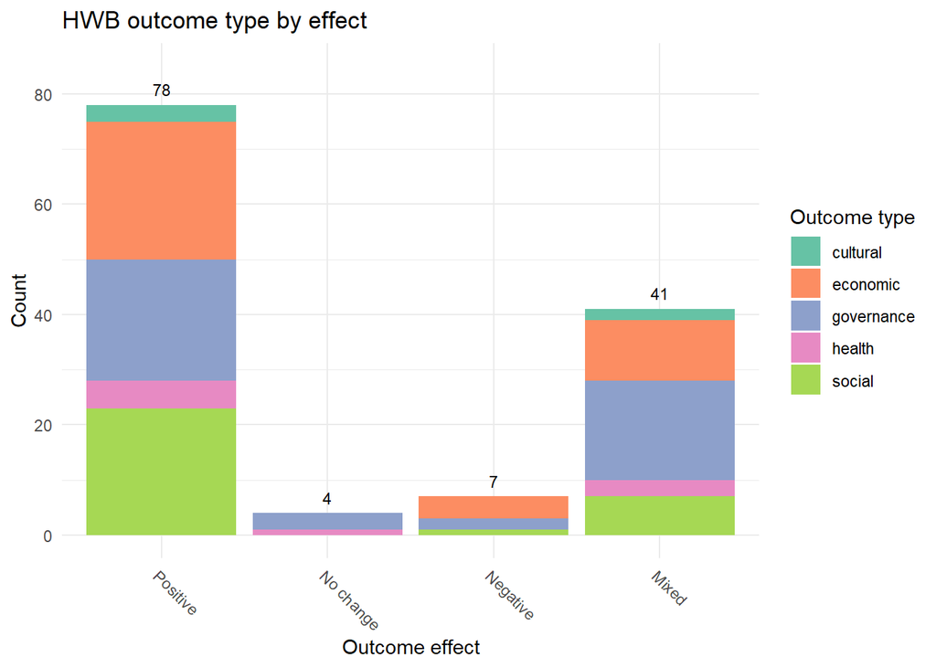

```r
plot <- fdata %>% select(id, hwbOutcome_type, hwbOutcome_effect) %>% filter(!is.na(hwbOutcome_effect)) %>% distinct()
plot <- plot %>% mutate(hwbOutcome_effect = factor(hwbOutcome_effect, levels = c("Positive", "No change", "Negative",  "Mixed"), ordered = TRUE))
colors <- scale_fill_brewer(palette = "Set2")
theme <- theme_minimal()
labels <- labs(title = "HWB outcome type by effect", x = "Outcome effect", y = "Count", fill = "Outcome type")

ggplot(plot, aes(x = hwbOutcome_effect)) + geom_bar(aes(fill = hwbOutcome_type)) + geom_text(stat = "count", size = 3, aes(label = ..count..), vjust = -0.75) + ylim(c(0, 85)) + theme + labels + theme(axis.text.x = element_text(angle = -45, hjust = 0)) + colors
```

## Cross-tabulations

### FWE comparisons

#### FWE vs. Use types

Counts reflected here are the number of observations (*not* the number of studies). A given study can have more than one observation.

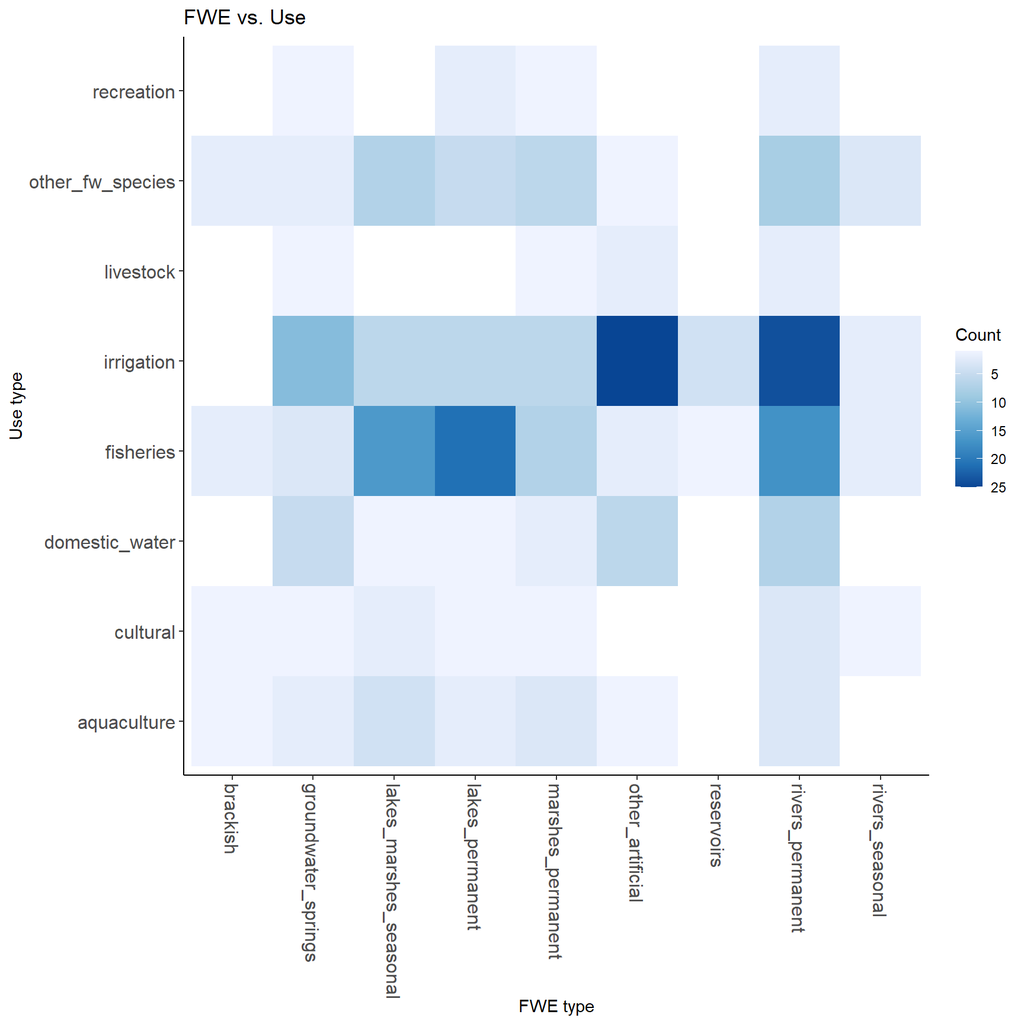

#### FWE vs. Action types

Counts reflected here are the number of observations (*not* the number of studies). A given study can have more than one observation.

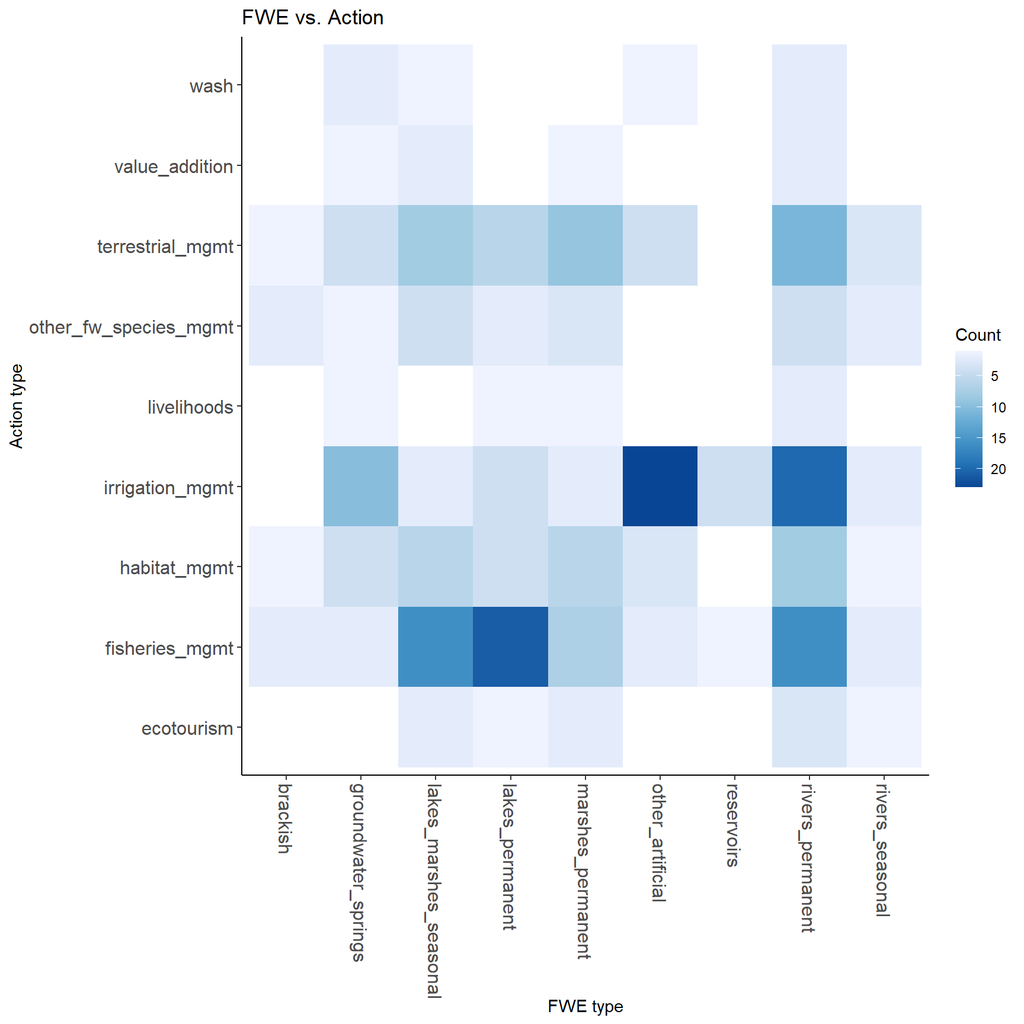

#### FWE vs. Env. outcomes (lumped)

Counts reflected here are the number of observations (*not* the number of studies). A given study can have more than one observation.

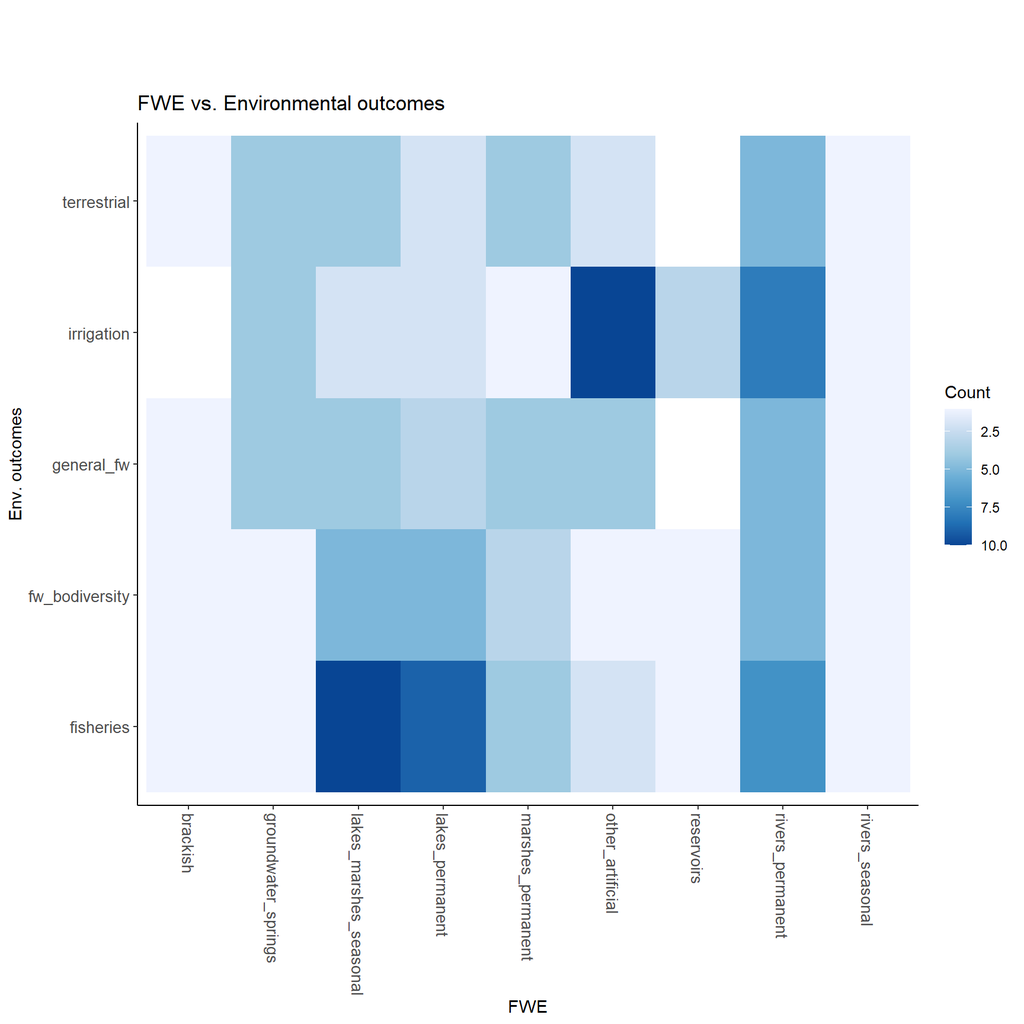

#### FWE vs. Env. outcomes (detailed)

Counts reflected here are the number of observations (*not* the number of studies). A given study can have more than one observation.

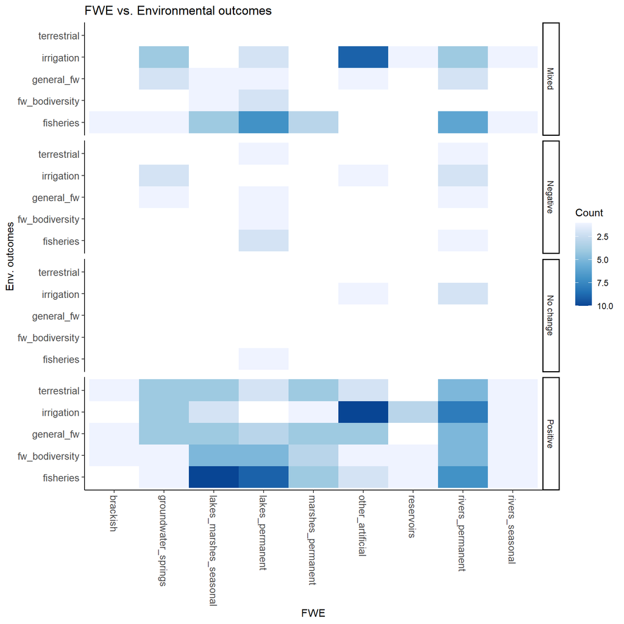

### Action comparisons

#### Action vs. Use types

Counts reflected here are the number of observations (*not* the number of studies). A given study can have more than one observation.

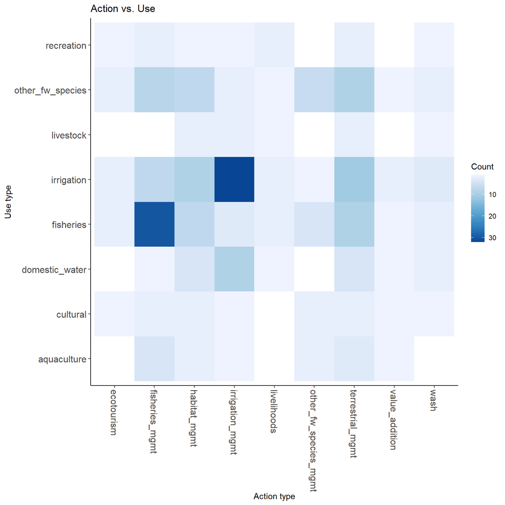

#### Actions vs. Env. outcomes (lumped)

Counts reflected here are the number of observations (*not* the number of studies). A given study can have more than one observation.

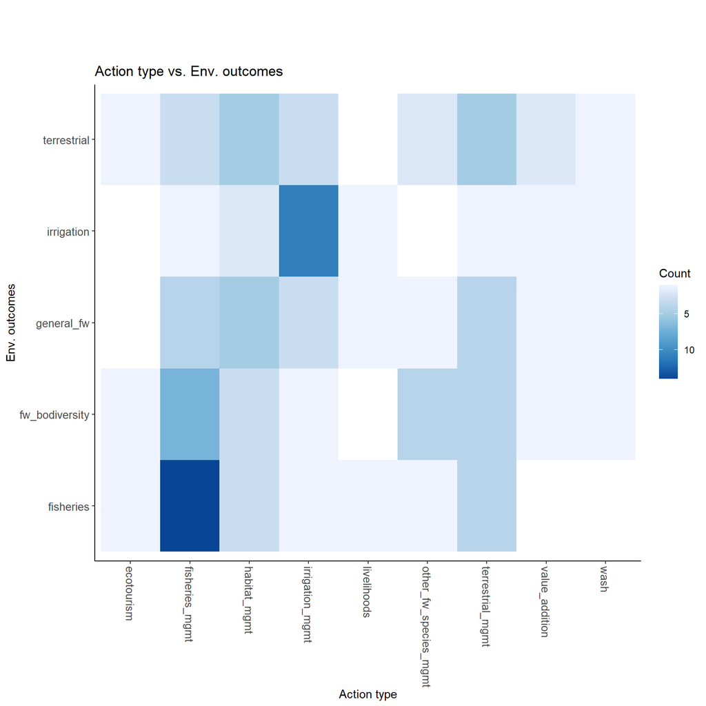

### Outcome comparisons

#### Env. vs. HWB outcomes (lumped)

Counts reflected here are the number of observations (*not* the number of studies). A given study can have more than one observation.

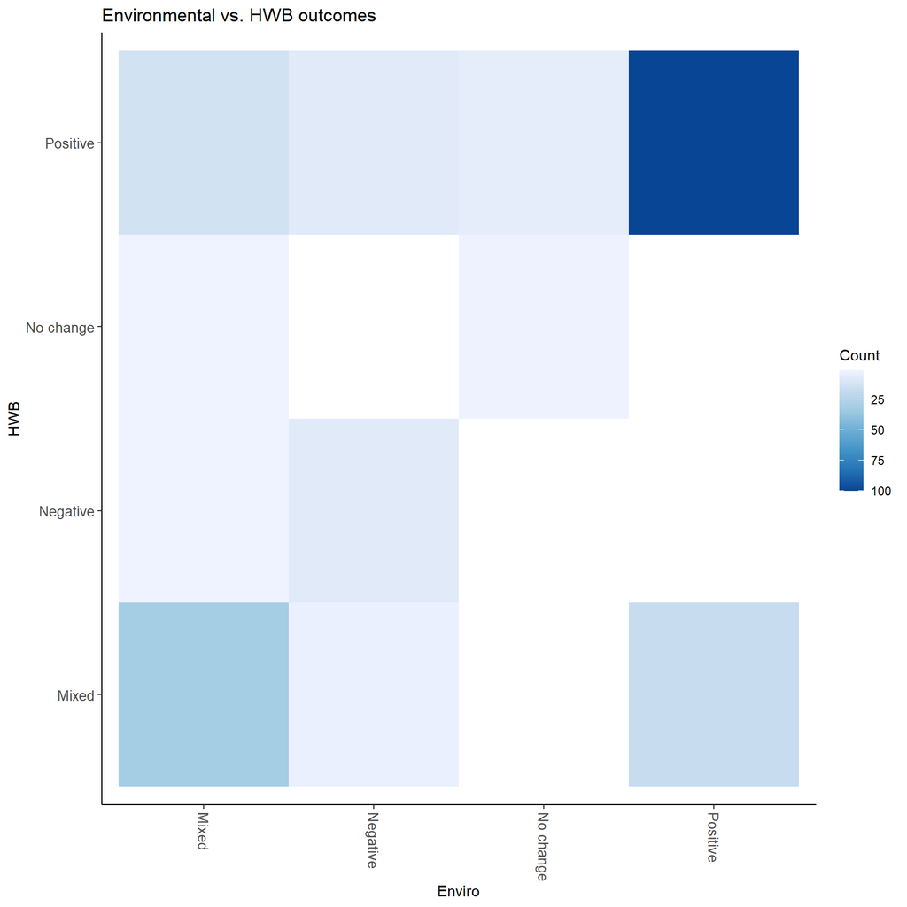

#### Env. vs. HWB outcomes (detailed)

Counts reflected here are the number of observations (*not* the number of studies). A given study can have more than one observation.

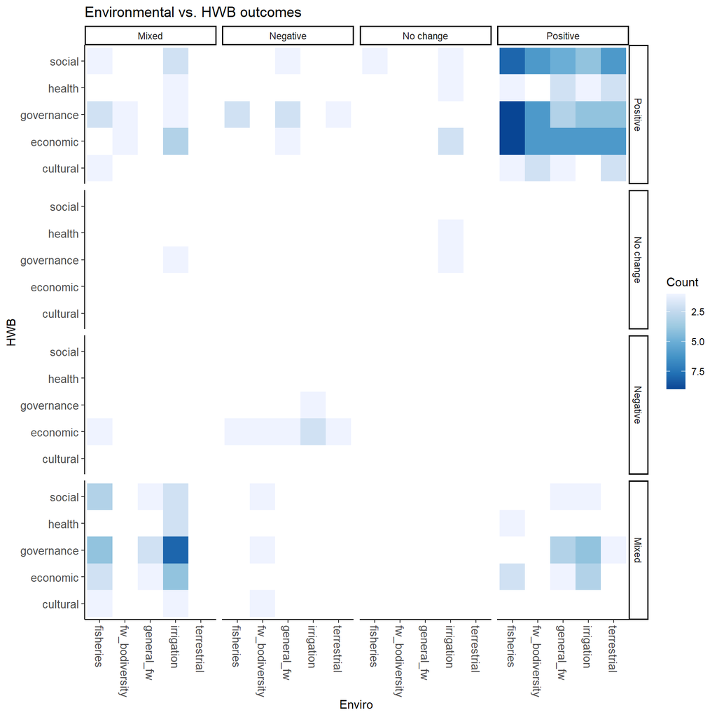

## Other results

### FWE type

Citation count by FWE type for studies with only one FWE type:

| fwe_type2 | n |
| --- | --- |
| brackish | 1 |
| groundwater_springs | 2 |
| lakes_marshes_seasonal | 1 |
| lakes_permanent | 9 |
| other_artificial | 6 |
| rivers_permanent | 6 |

### Use type

Citation count by use type for studies with only one use type:

| use_type | n |
| --- | --- |
| fisheries | 18 |
| irrigation | 22 |
| other_fw_species | 2 |

Citation count by use type for studies with *greater* than one use type excluding fisheries & irrigation:

| use_type | n |
| --- | --- |
| aquaculture | 5 |
| cultural | 3 |
| domestic_water | 12 |
| livestock | 3 |
| other_fw_species | 10 |
| recreation | 3 |

### Action type

Citation count by action type for studies with only one action type:

| action_type | n |
| --- | --- |
| fisheries_mgmt | 21 |
| irrigation_mgmt | 25 |
| other_fw_species_mgmt | 1 |
| terrestrial_mgmt | 1 |

### Outcome type

Citation count by env. outcome type for studies with only one env. outcome type:

| enviroOutcome_type | n |
| --- | --- |
| fisheries | 14 |
| fw_bodiversity | 1 |
| irrigation | 22 |
| terrestrial | 1 |

## Comparison of cross-tab styles

Selection of possible graphic styles for displaying cross-tabulation results for comparisons across variables. Examples here show comparisons between FWE types vs. use types.

### Sankey diagram

[interactive chart not shown]

### Heatmap

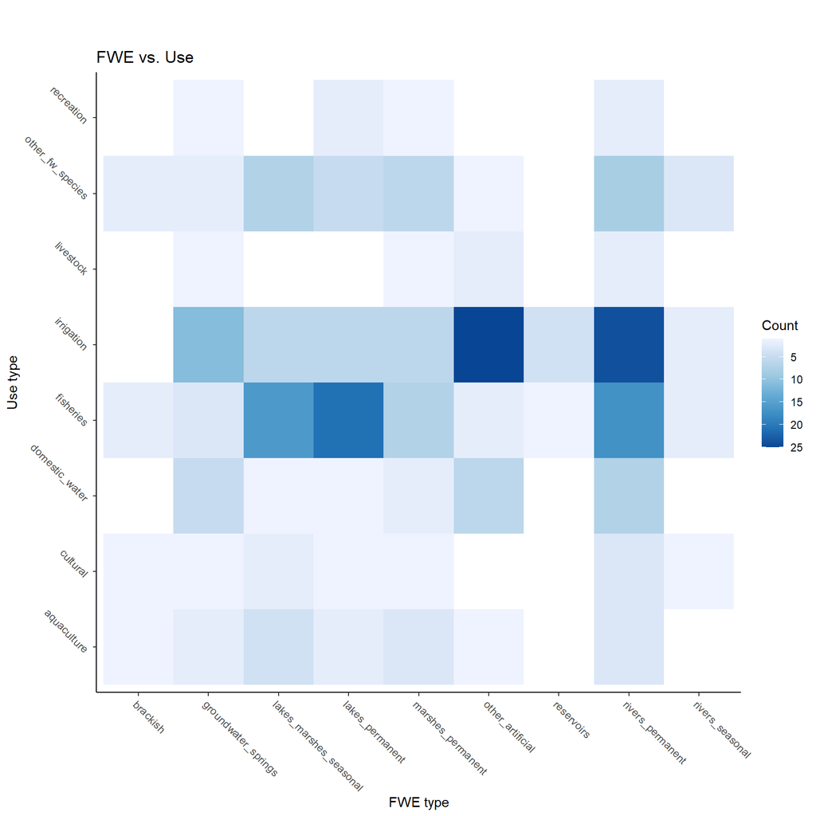

### Heatmap (%)

Heatmap with counts relative to the total number of studies within each FWE type (equivalent to stacked percent bar plot).

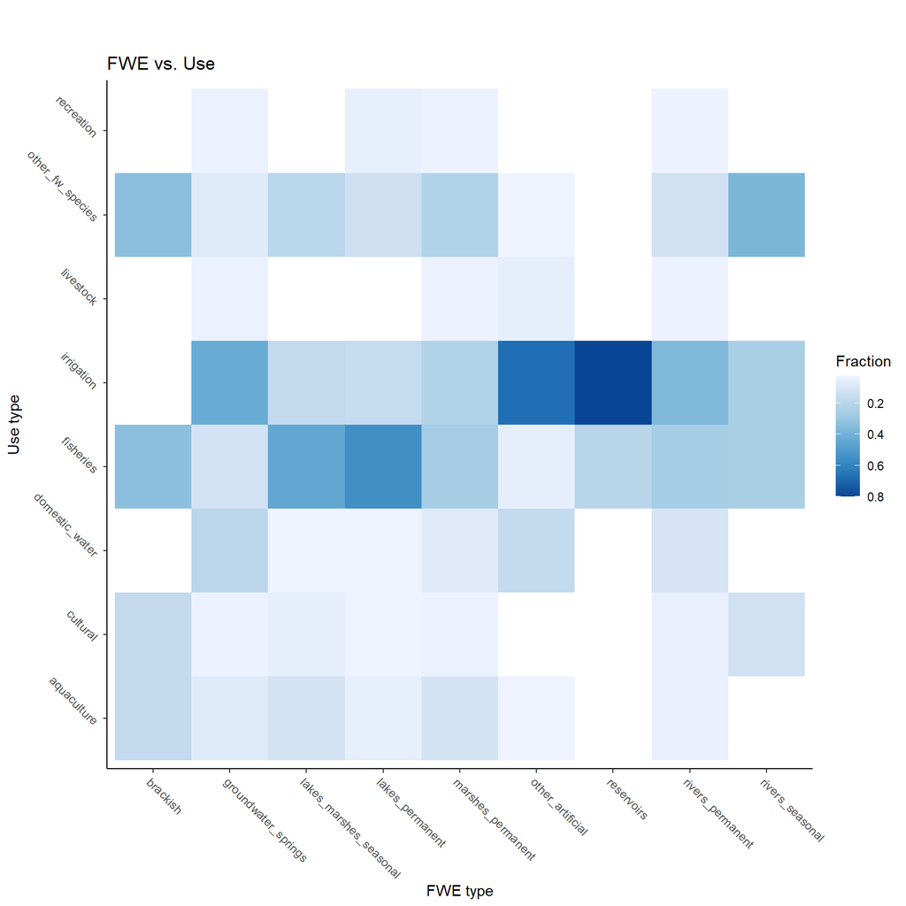

### Heatmap circles

Heatmap with circles (a) *sized* relative to absolute counts and (b) *colored* relative to the total number of studies within each FWE type (equivalent to stacked percent bar plot).

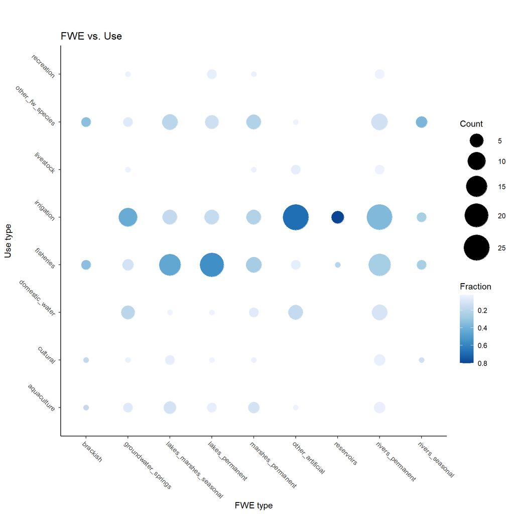